# Central limit theorem simply explained

NDH802 - R Application

### Key takeaways

- Distribution of the random variable $X$ is **different from** the distribution of the sample mean $\bar{X}$.
- When number of observations is large, the the distribution of the sample mean $\bar{X}$ converges (approximates) to the normal distribution $N(\mu,\frac{\sigma^2}{n})$

In the beginning of the course, we have a checklist that includes 4 questions (i.e., `size =`4). Each question has 2 possible responses, “true” or “false” (hence binomial). Assume the probability is 75% that the students choose “true” (i.e., `prob =`0.75) on each question. That’s the same old binomial distribution, $number\_of\_response\_true \sim Bin$(4, 0.75) and can be illustrated by this blue-ish bar plot with `n =`70 (because we have 70 students).

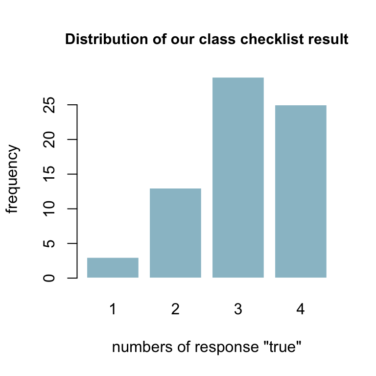

We can easily compute the **mean** of number of the response “true” in our class, which is 3.1 (i.e., on average, each of you choose 3.1 responses “true” over 4 questions).

So far so good? Now, what I’m going to say does take a bit of imagination. If you watch tons of sci-fi movies/series, it would be a bit easier. Anyway, imagine there are 1000 parallel realities, or universes if you will. Within each reality, there is a NDH802 class. By some miracle we can collect their checklist results, then compute the **mean** of number of the response “true” of each and every classes, exactly like what we did earlier.

Now we have a set of 1000 **means**, right? **The Central Limit Theorem suggests that when we have a huge number of observations (the number of realities in our case), these **means** follow a normal distribution.** Formally, when $n$ is large, $\bar{X_n} \sim N(\mu,\frac{\sigma^2}{n})$.

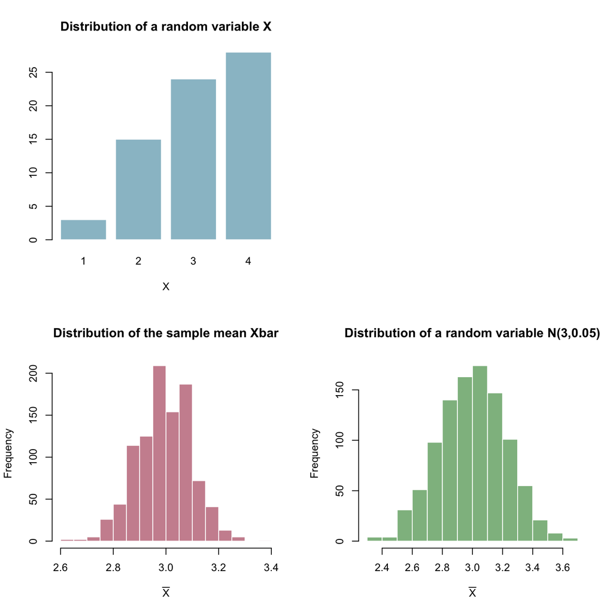

In summary,